# Assignment 1

Kavin

2/17/2021

### Importing necessary libraries

```r
library(knitr)
library(PerformanceAnalytics)
```

```r
library(ggplot2)
library(stargazer)
```

Reading the dataset to be analyzed

```r
setwd("C:/College/Courses/SDM/")
d <- read.csv('CreditRating.csv')
```

```r
kable(d[1:10,], caption = "Credit Ratings")
```

Credit Ratings

| ID | Income | Limit | Rating | Cards | Age | Education | Gender | Student | Married | Ethnicity | Balance |
| --- | --- | --- | --- | --- | --- | --- | --- | --- | --- | --- | --- |
| 1 | 14.891 | 3606 | 283 | 2 | 34 | 11 | Male | No | Yes | Caucasian | 333 |
| 2 | 106.025 | 6645 | 483 | 3 | 82 | 15 | Female | Yes | Yes | Hispanic | 903 |
| 3 | 104.593 | 7075 | 514 | 4 | 71 | 11 | Male | No | No | Hispanic | 580 |
| 4 | 148.924 | 9504 | 681 | 3 | 36 | 11 | Female | No | No | Hispanic | 964 |
| 5 | 55.882 | 4897 | 357 | 2 | 68 | 16 | Male | No | Yes | Caucasian | 331 |
| 6 | 80.180 | 8047 | 569 | 4 | 77 | 10 | Male | No | No | Caucasian | 1151 |
| 7 | 20.996 | 3388 | 259 | 2 | 37 | 12 | Female | No | No | African American | 203 |
| 8 | 71.408 | 7114 | 512 | 2 | 87 | 9 | Male | No | No | Hispanic | 872 |
| 9 | 15.125 | 3300 | 266 | 5 | 66 | 13 | Female | No | No | Caucasian | 279 |
| 10 | 71.061 | 6819 | 491 | 3 | 41 | 19 | Female | Yes | Yes | African American | 1350 |

Dropping the column ID

```r
d <- d[,-1]
```

Data Transformation - Computing Credit utilization.

```r
d$CreditUtilization <- with(d, Balance/Limit)
```

Checking for null values

```r
colSums((is.na(d)))
```

```
##            Income             Limit            Rating             Cards
##                 0                 0                 0                 0
##               Age         Education            Gender           Student
##                 0                 0                 0                 0
##           Married         Ethnicity           Balance CreditUtilization
##                 0                 0                 0                 0
```

### EDA

```r
summary(d)
```

```
##      Income           Limit           Rating          Cards
##  Min.   : 10.35   Min.   :  855   Min.   : 93.0   Min.   :1.000
##  1st Qu.: 21.01   1st Qu.: 3088   1st Qu.:247.2   1st Qu.:2.000
##  Median : 33.12   Median : 4622   Median :344.0   Median :3.000
##  Mean   : 45.22   Mean   : 4736   Mean   :354.9   Mean   :2.958
##  3rd Qu.: 57.47   3rd Qu.: 5873   3rd Qu.:437.2   3rd Qu.:4.000
##  Max.   :186.63   Max.   :13913   Max.   :982.0   Max.   :9.000
##       Age          Education        Gender            Student
##  Min.   :23.00   Min.   : 5.00   Length:400         Length:400
##  1st Qu.:41.75   1st Qu.:11.00   Class :character   Class :character
##  Median :56.00   Median :14.00   Mode  :character   Mode  :character
##  Mean   :55.67   Mean   :13.45
##  3rd Qu.:70.00   3rd Qu.:16.00
##  Max.   :98.00   Max.   :20.00
##    Married           Ethnicity            Balance        CreditUtilization
##  Length:400         Length:400         Min.   :   0.00   Min.   :0.00000
##  Class :character   Class :character   1st Qu.:  68.75   1st Qu.:0.01851
##  Mode  :character   Mode  :character   Median : 459.50   Median :0.09873
##                                        Mean   : 520.01   Mean   :0.08958
##                                        3rd Qu.: 863.00   3rd Qu.:0.14325
##                                        Max.   :1999.00   Max.   :0.27693
```

### Visualizations

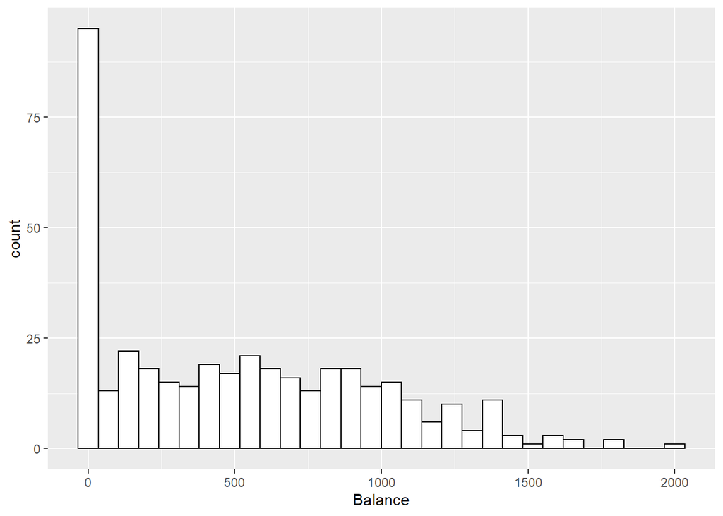

The dependant variable is not uniformly distributed.

Using performance analytics to visualize the data

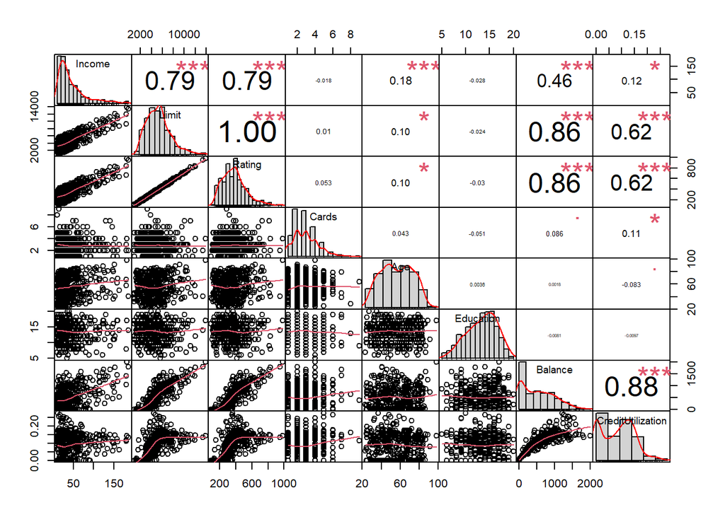

We should drop Limit from our model because credit limits are not a cause for credit ratings.

Correlations:

Rating and Balance - 0.86 Rating and Income - 0.79 Rating and Credit Utilization - 0.62 Income and Balance - 0.46

#### Doing interaction plots to understand the relationship between our categorical variables and numerical variables:

##### Does ethnicity have an effect on credit ratings based on the given data?

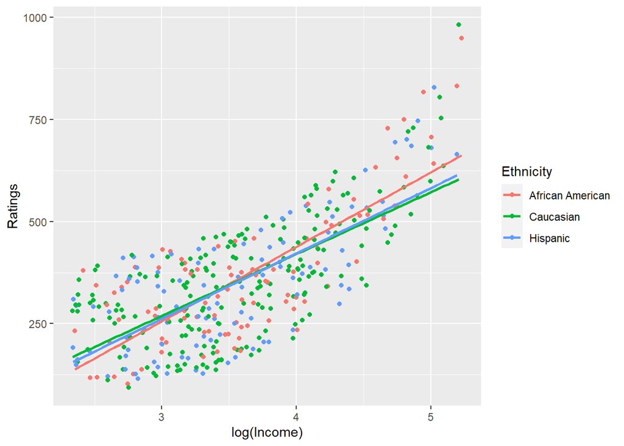

For lower income, there seems to be some bias against African Americans when comes to lower levels of come. However, as the income increases, the data suggests the opposite. There are low data points for higher income so we cannot infer from the sample data.

Does gender have an effect on credit ratings based on the given data?

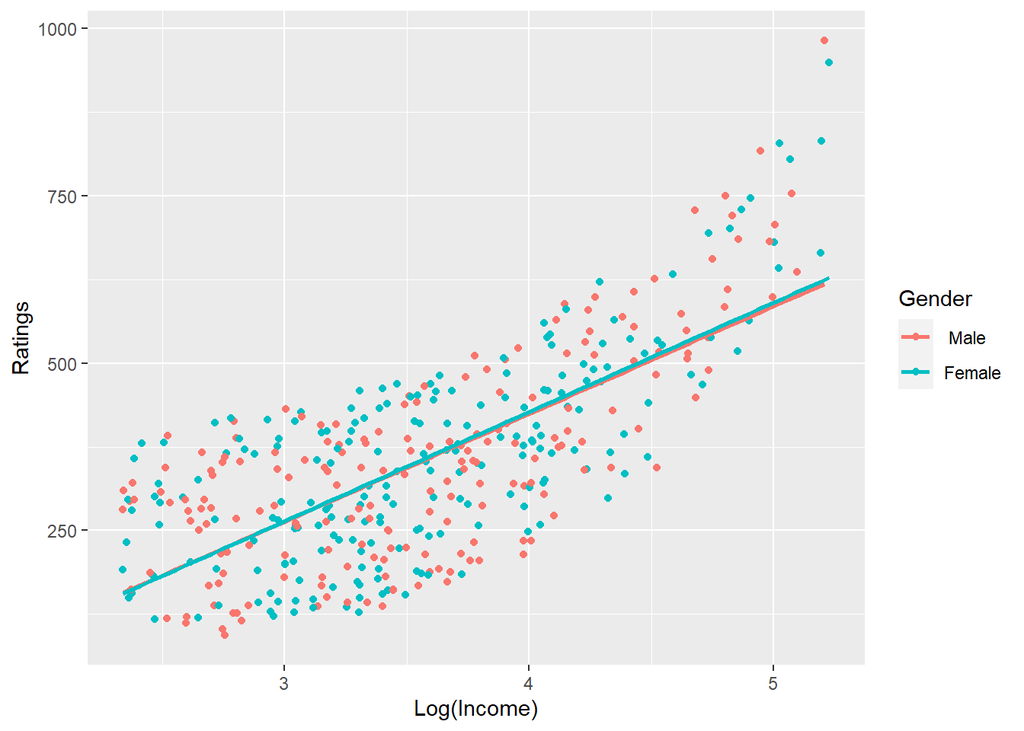

The lines are almost parallel, this suggests that there is no effect.

Does being married have an effect on credit ratings based on the given data?

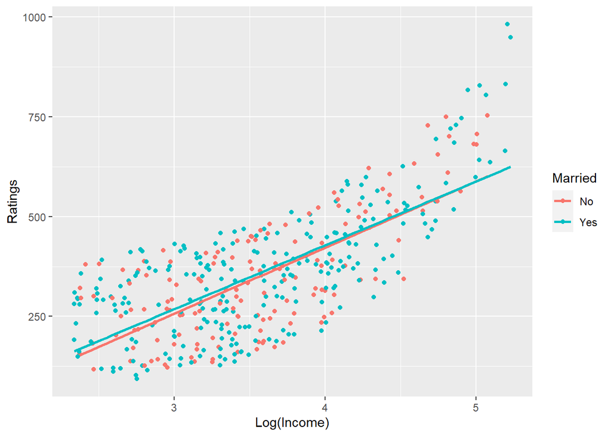

The lines are almost parallel, this suggests that there is no effect.

Do students have higher credit balance ?

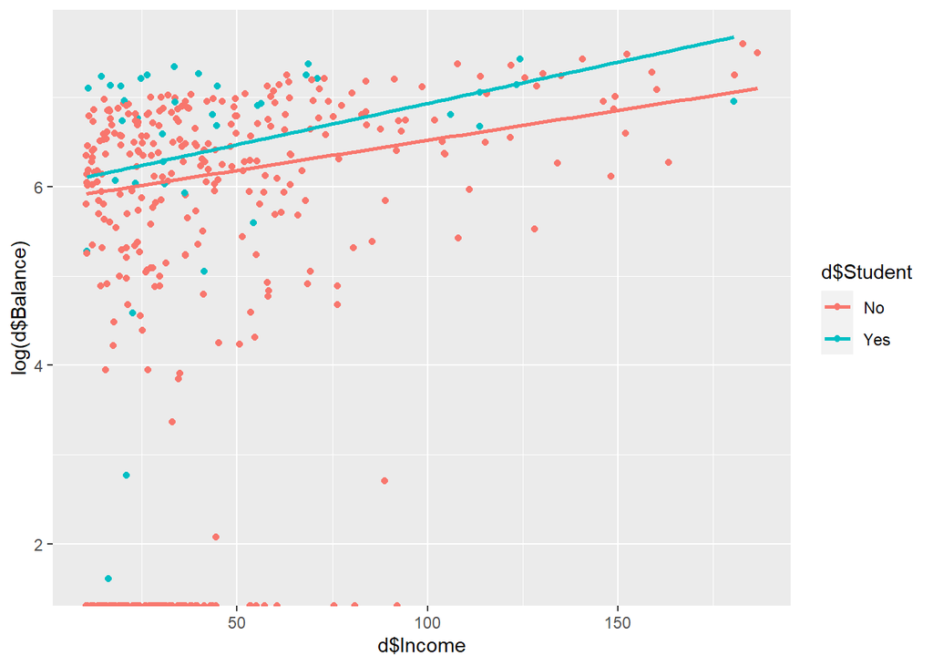

We do not have enough data on students.

Does education years has a positive linear relationship with income?

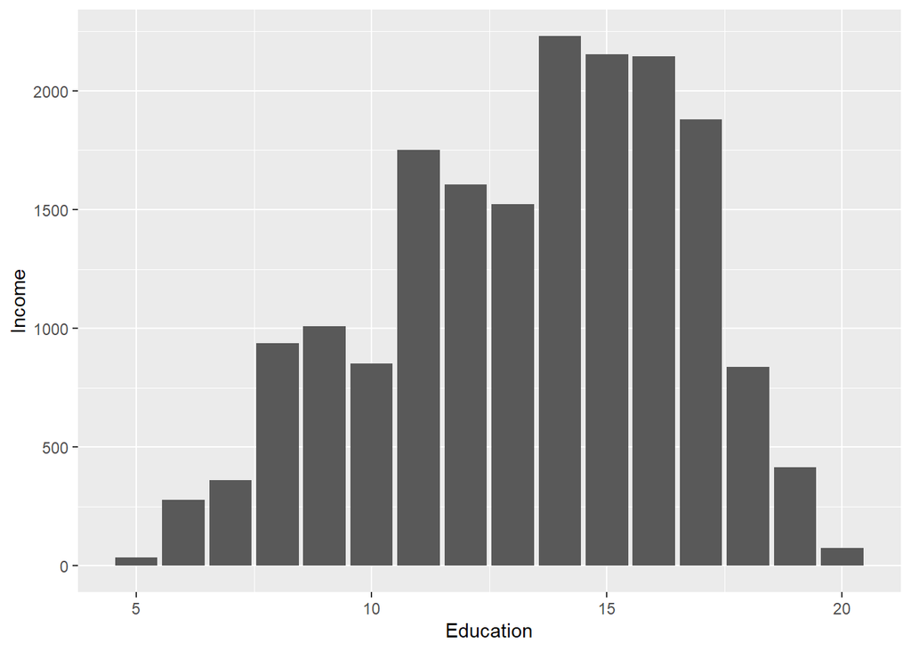

### Models

Simple regression model

```r
m1 <- lm(Rating ~ Income + Age + Balance + Cards + Ethnicity + Gender + Education + Student , data=d)
summary(m1)
```

```
##
## Call:
## lm(formula = Rating ~ Income + Age + Balance + Cards + Ethnicity +
##     Gender + Education + Student, data = d)
##
## Residuals:
##     Min      1Q  Median      3Q     Max
## -78.606 -11.801   4.239  17.351  44.469
##
## Coefficients:
##                      Estimate Std. Error t value Pr(>|t|)
## (Intercept)        143.805171   8.037594  17.892   <2e-16 ***
## Income               2.064803   0.041292  50.005   <2e-16 ***
## Age                  0.116104   0.074254   1.564    0.119
## Balance              0.233892   0.003238  72.230   <2e-16 ***
## Cards               -0.387734   0.921924  -0.421    0.674
## EthnicityCaucasian  -2.172242   3.078257  -0.706    0.481
## EthnicityHispanic   -5.139558   3.537733  -1.453    0.147
## GenderFemale         3.004784   2.505394   1.199    0.231
## Education            0.112292   0.402186   0.279    0.780
## StudentYes         -98.510712   4.371399 -22.535   <2e-16 ***
## ---
## Signif. codes:  0 '***' 0.001 '**' 0.01 '*' 0.05 '.' 0.1 ' ' 1
##
## Residual standard error: 24.98 on 390 degrees of freedom
## Multiple R-squared:  0.9745, Adjusted R-squared:  0.9739
## F-statistic:  1658 on 9 and 390 DF,  p-value: < 2.2e-16
```

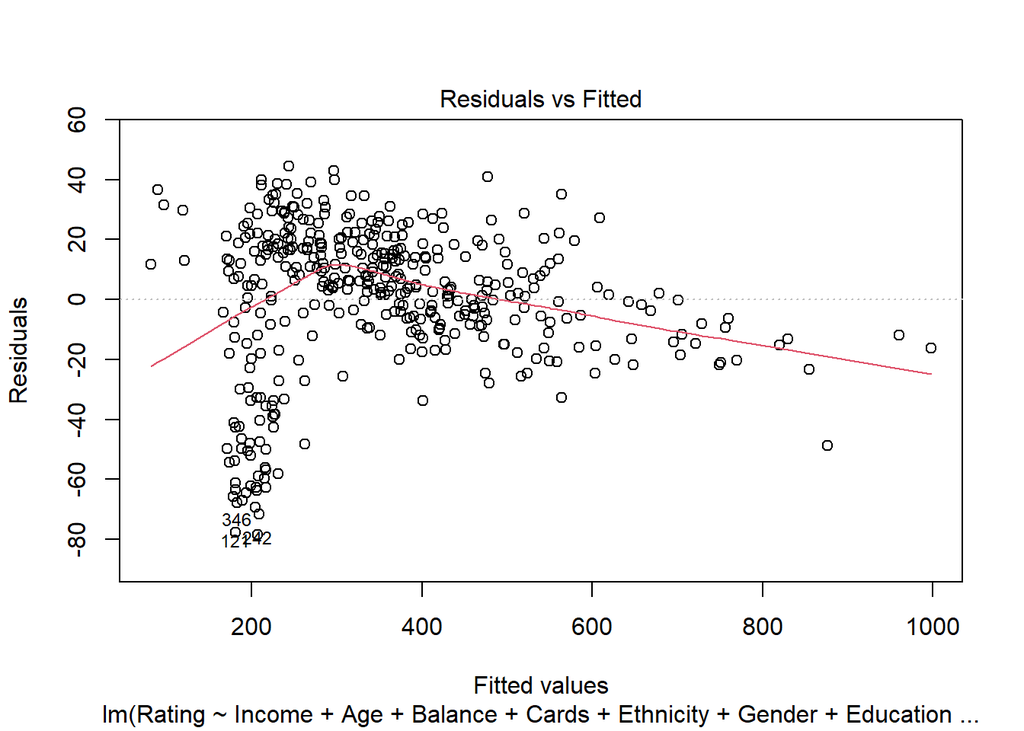

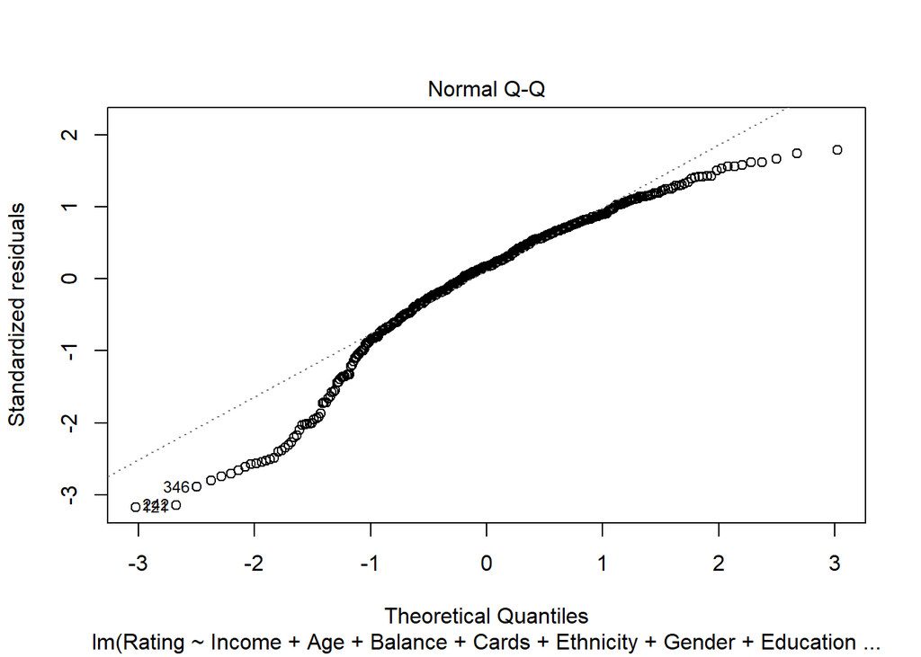

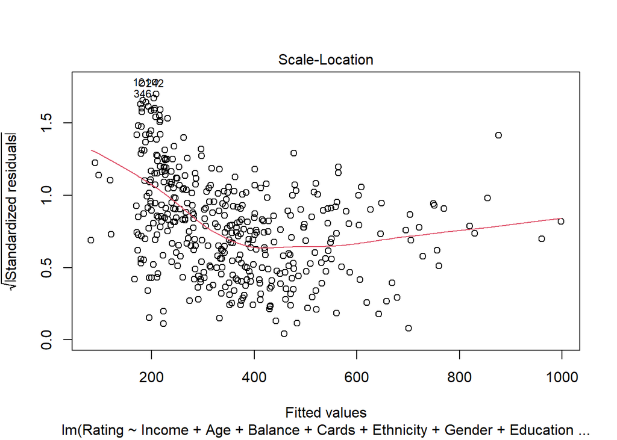

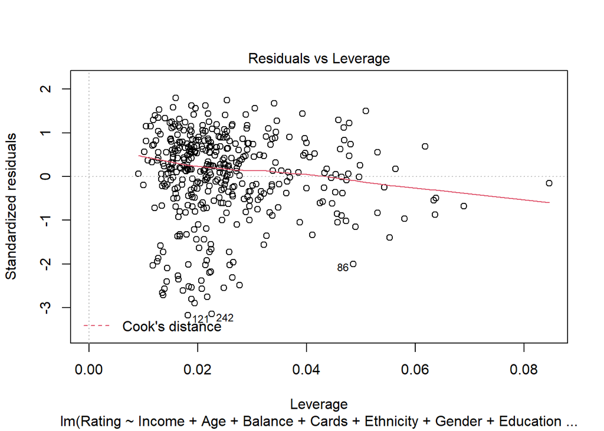

```r
plot(m1)
```

Inferences: - The DV’s explain 97% of the variability. But the model fails the OLS assumptions test, as we can see from the QQ plot and Residuals va fitted plot. Therefore this model is biased. - For the given data, P values for the remaining variables are high so we cannot reject the null hypothesis

```r
m2 <- lm(Rating ~ Age  + Cards + Ethnicity + Gender + Education + Student , data=d)
summary(m2)
```

```
##
## Call:
## lm(formula = Rating ~ Age + Cards + Ethnicity + Gender + Education +
##     Student, data = d)
##
## Residuals:
##     Min      1Q  Median      3Q     Max
## -266.15 -110.15  -12.71   82.58  603.07
##
## Coefficients:
##                    Estimate Std. Error t value Pr(>|t|)
## (Intercept)        315.1754    49.0537   6.425 3.82e-10 ***
## Age                  0.8834     0.4514   1.957    0.051 .
## Cards                5.4193     5.6707   0.956    0.340
## EthnicityCaucasian  -8.8614    19.0793  -0.464    0.643
## EthnicityHispanic  -16.5811    21.9299  -0.756    0.450
## GenderFemale         3.1177    15.5320   0.201    0.841
## Education           -1.3876     2.4926  -0.557    0.578
## StudentYes           2.4477    25.9773   0.094    0.925
## ---
## Signif. codes:  0 '***' 0.001 '**' 0.01 '*' 0.05 '.' 0.1 ' ' 1
##
## Residual standard error: 154.9 on 392 degrees of freedom
## Multiple R-squared:  0.01536,    Adjusted R-squared:  -0.002226
## F-statistic: 0.8734 on 7 and 392 DF,  p-value: 0.5275
```

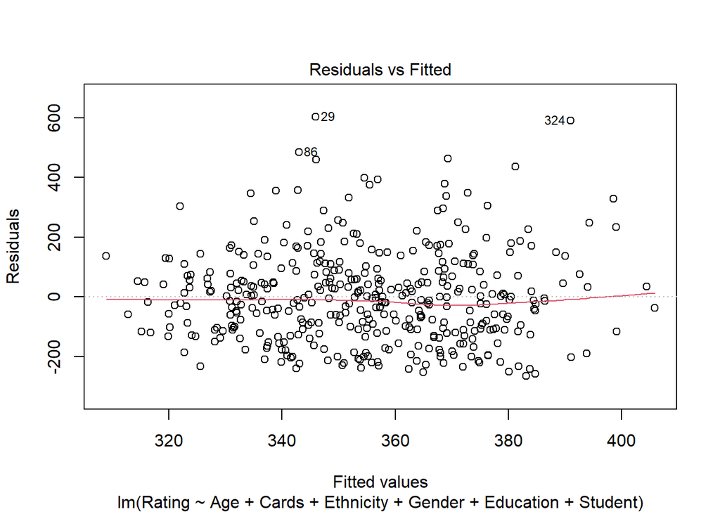

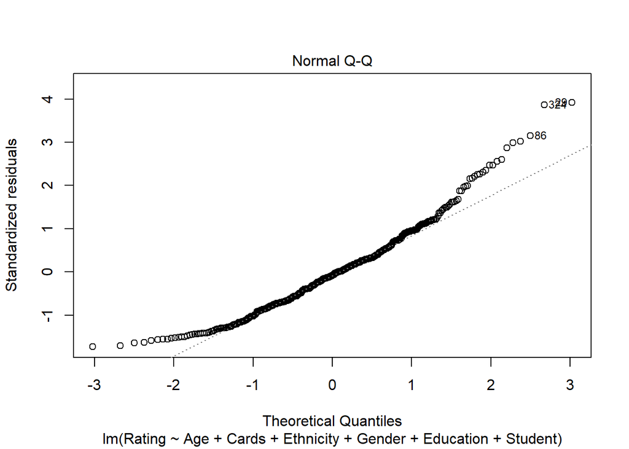

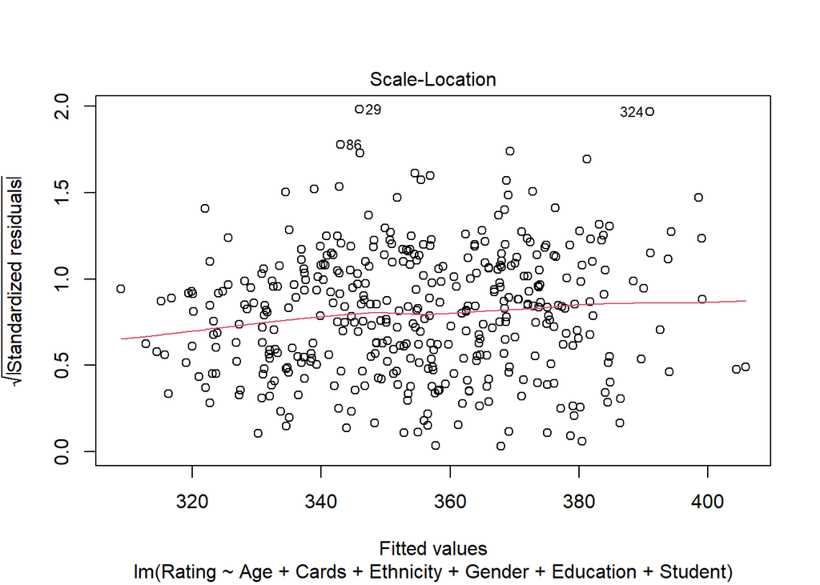

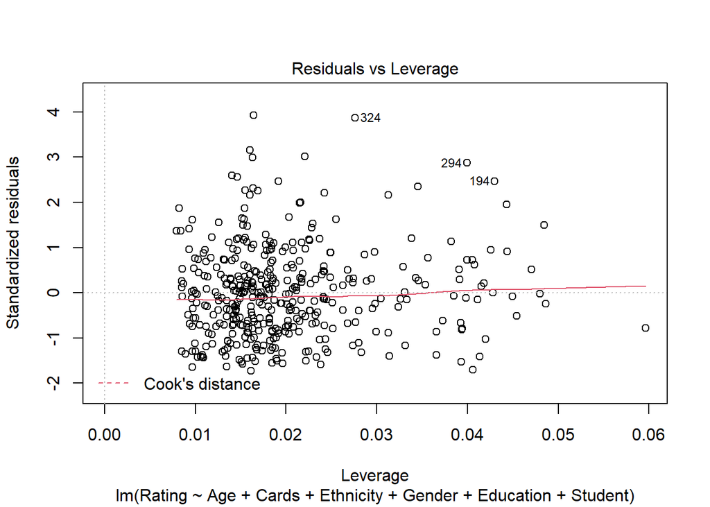

```r
plot(m2)
```

Trying With interaction effects

```r
m3 <- lm(Rating ~  Income + Age + Balance + Cards + Education + Ethnicity + Gender + Student + CreditUtilization + Income*Ethnicity + Income*Gender + Income*Education, data=d)
summary(m3)
```

```
##
## Call:
## lm(formula = Rating ~ Income + Age + Balance + Cards + Education +
##     Ethnicity + Gender + Student + CreditUtilization + Income *
##     Ethnicity + Income * Gender + Income * Education, data = d)
##
## Residuals:
##     Min      1Q  Median      3Q     Max
## -68.639 -11.355   1.325  13.250  69.761
##
## Coefficients:
##                             Estimate Std. Error t value Pr(>|t|)
## (Intercept)                1.152e+02  1.007e+01  11.437   <2e-16 ***
## Income                     2.506e+00  1.497e-01  16.735   <2e-16 ***
## Age                        1.646e-01  6.526e-02   2.522   0.0121 *
## Balance                    1.460e-01  8.604e-03  16.969   <2e-16 ***
## Cards                     -1.024e+00  8.080e-01  -1.267   0.2059
## Education                  6.019e-01  5.799e-01   1.038   0.2999
## EthnicityCaucasian        -6.897e+00  4.408e+00  -1.565   0.1185
## EthnicityHispanic         -6.284e+00  4.936e+00  -1.273   0.2038
## GenderFemale               3.404e+00  3.627e+00   0.939   0.3485
## StudentYes                -1.194e+02  4.278e+00 -27.919   <2e-16 ***
## CreditUtilization          6.004e+02  5.482e+01  10.951   <2e-16 ***
## Income:EthnicityCaucasian  5.647e-02  7.665e-02   0.737   0.4618
## Income:EthnicityHispanic   3.393e-02  8.470e-02   0.401   0.6890
## Income:GenderFemale       -1.950e-02  6.526e-02  -0.299   0.7652
## Income:Education          -5.710e-03  1.013e-02  -0.564   0.5734
## ---
## Signif. codes:  0 '***' 0.001 '**' 0.01 '*' 0.05 '.' 0.1 ' ' 1
##
## Residual standard error: 21.78 on 385 degrees of freedom
## Multiple R-squared:  0.9809, Adjusted R-squared:  0.9802
## F-statistic:  1410 on 14 and 385 DF,  p-value: < 2.2e-16
```

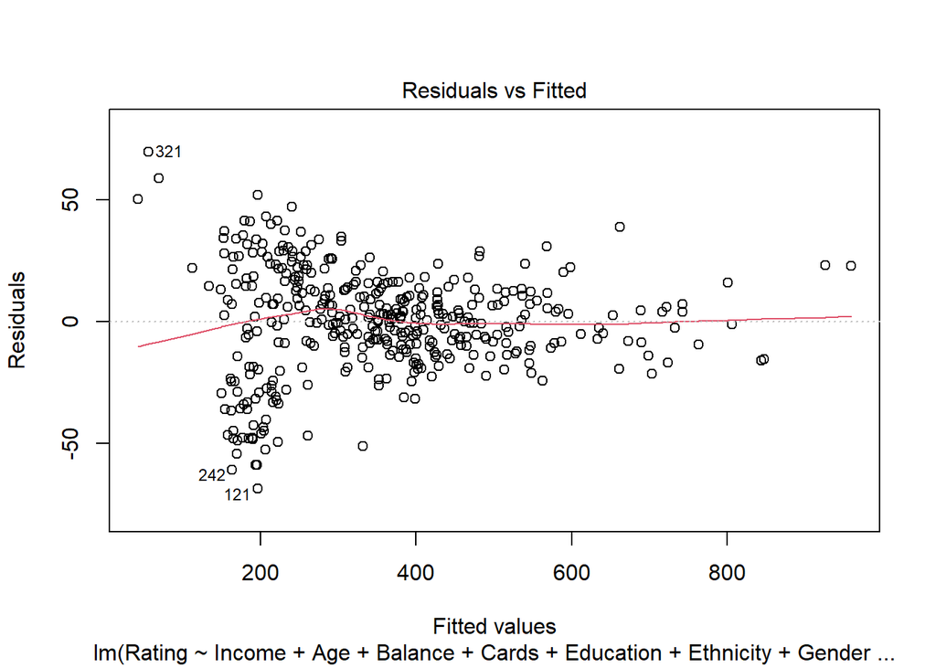

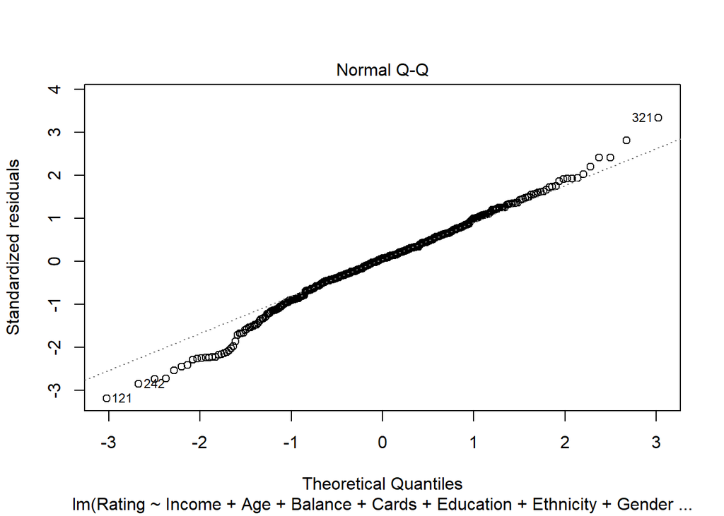

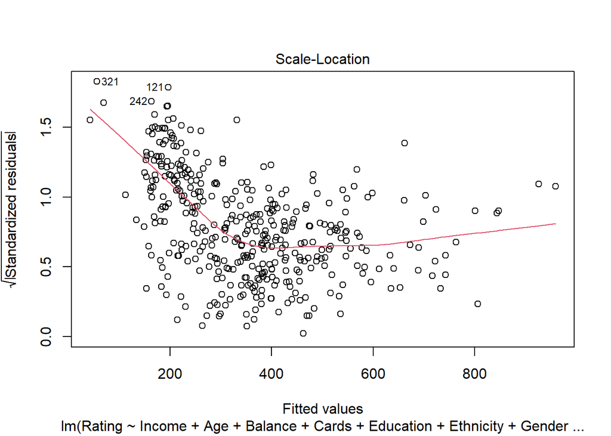

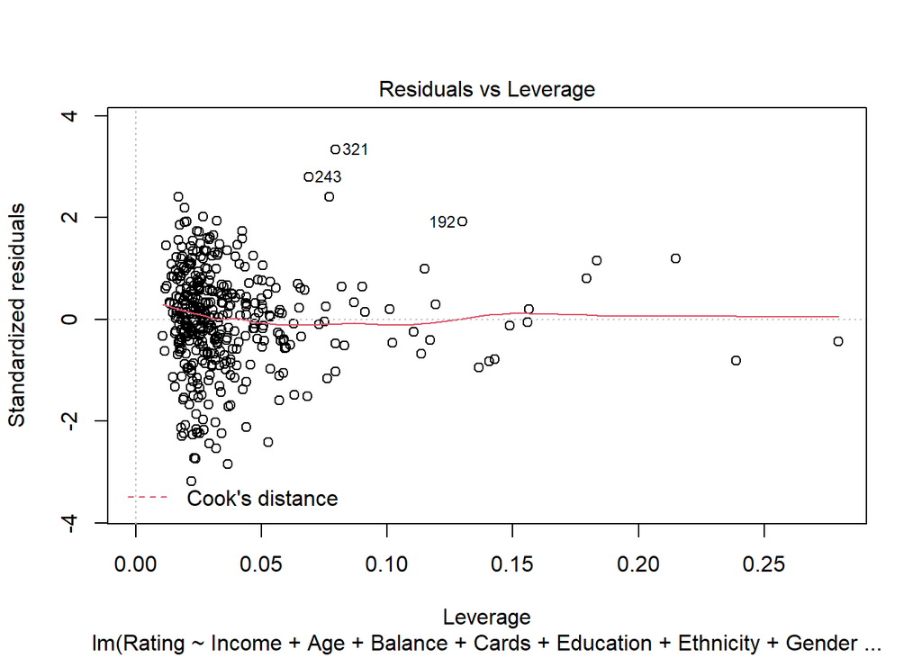

```r
plot(m3)
```

- None of the interaction effects are significant

```r
m4 <- lm(Rating ~  Income + Age + Balance + Cards + Education + Ethnicity + Gender + Student + CreditUtilization, data=d)
summary(m4)
```

```
##
## Call:
## lm(formula = Rating ~ Income + Age + Balance + Cards + Education +
##     Ethnicity + Gender + Student + CreditUtilization, data = d)
##
## Residuals:
##     Min      1Q  Median      3Q     Max
## -68.391 -11.430   0.809  13.746  70.757
##
## Coefficients:
##                      Estimate Std. Error t value Pr(>|t|)
## (Intercept)         1.168e+02  7.378e+00  15.827  < 2e-16 ***
## Income              2.460e+00  5.004e-02  49.155  < 2e-16 ***
## Age                 1.676e-01  6.465e-02   2.592  0.00991 **
## Balance             1.445e-01  8.385e-03  17.237  < 2e-16 ***
## Cards              -1.011e+00  8.026e-01  -1.259  0.20861
## Education           3.741e-01  3.501e-01   1.069  0.28590
## EthnicityCaucasian -4.448e+00  2.681e+00  -1.659  0.09793 .
## EthnicityHispanic  -4.776e+00  3.073e+00  -1.554  0.12093
## GenderFemale        2.570e+00  2.176e+00   1.181  0.23830
## StudentYes         -1.198e+02  4.238e+00 -28.272  < 2e-16 ***
## CreditUtilization   6.084e+02  5.377e+01  11.315  < 2e-16 ***
## ---
## Signif. codes:  0 '***' 0.001 '**' 0.01 '*' 0.05 '.' 0.1 ' ' 1
##
## Residual standard error: 21.69 on 389 degrees of freedom
## Multiple R-squared:  0.9808, Adjusted R-squared:  0.9803
## F-statistic:  1991 on 10 and 389 DF,  p-value: < 2.2e-16
```

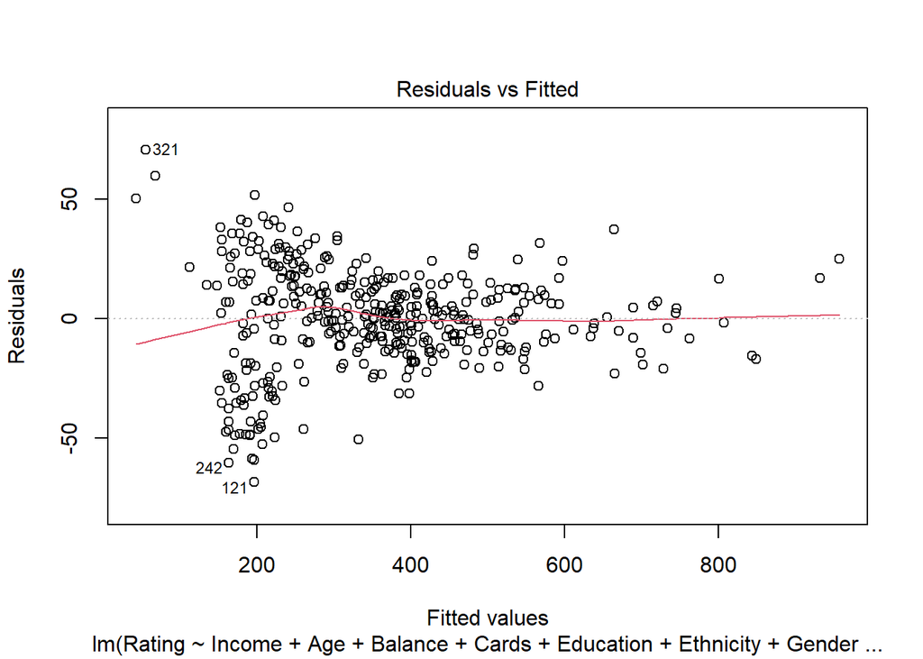

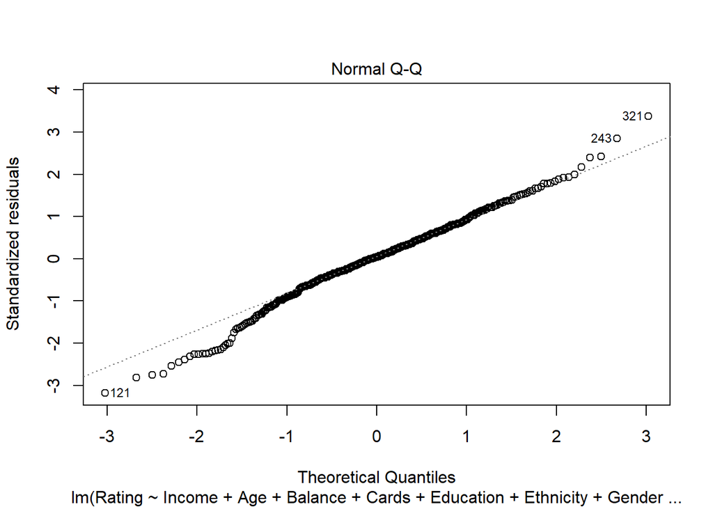

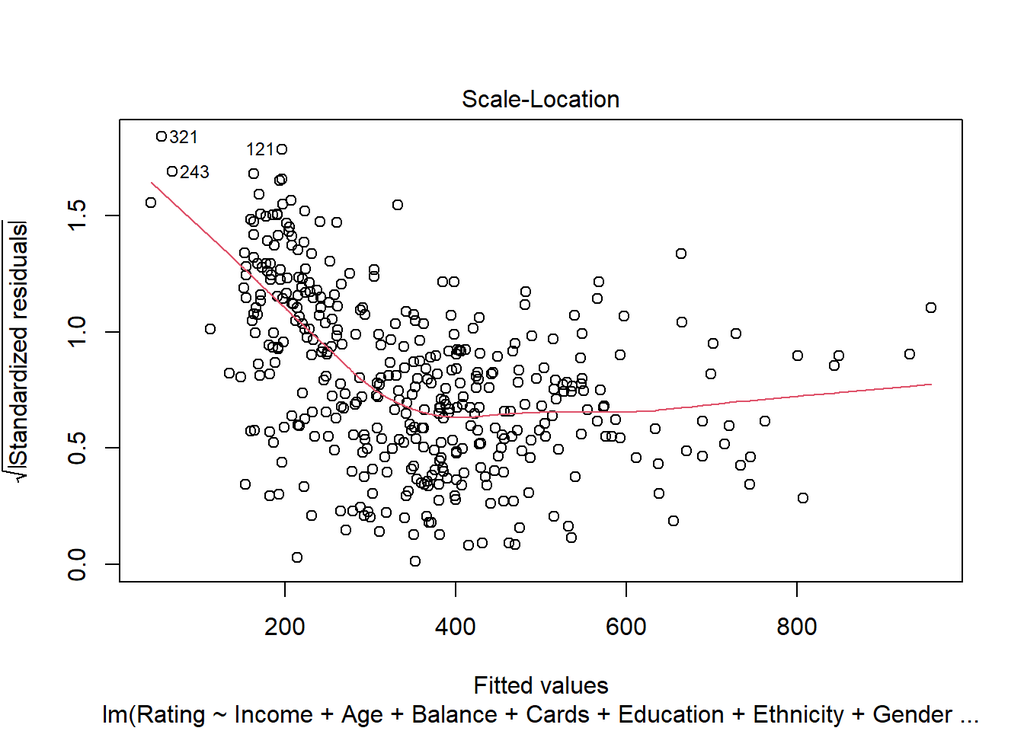

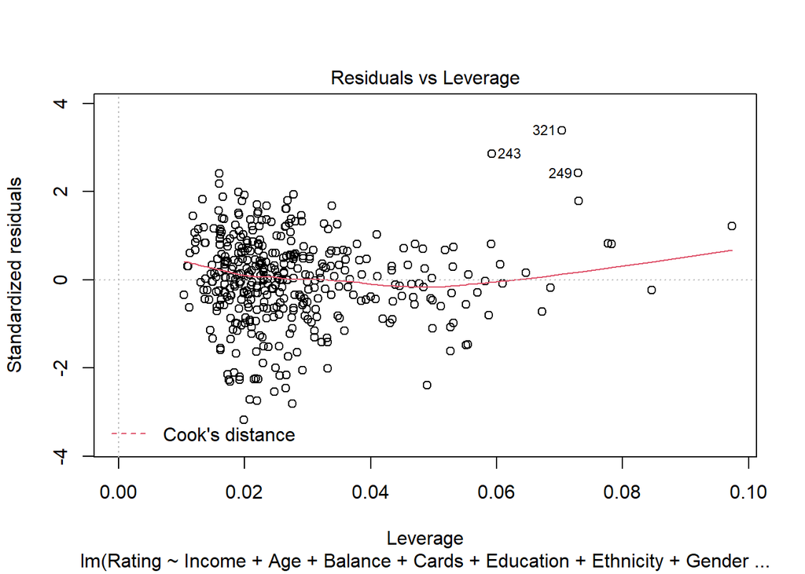

```r
plot(m4)
```

```r
stargazer(m3,m4, title="Results", type = "text")
```

```
##
## Results
## =================================================================================
##                                             Dependent variable:
##                           -------------------------------------------------------
##                                                   Rating
##                                       (1)                         (2)
## ---------------------------------------------------------------------------------
## Income                             2.506***                    2.460***
##                                     (0.150)                     (0.050)
##
## Age                                 0.165**                    0.168***
##                                     (0.065)                     (0.065)
##
## Balance                            0.146***                    0.145***
##                                     (0.009)                     (0.008)
##
## Cards                               -1.024                      -1.011
##                                     (0.808)                     (0.803)
##
## Education                            0.602                       0.374
##                                     (0.580)                     (0.350)
##
## EthnicityCaucasian                  -6.897                      -4.448*
##                                     (4.408)                     (2.681)
##
## EthnicityHispanic                   -6.284                      -4.776
##                                     (4.936)                     (3.073)
##
## GenderFemale                         3.404                       2.570
##                                     (3.627)                     (2.176)
##
## StudentYes                        -119.445***                 -119.820***
##                                     (4.278)                     (4.238)
##
## CreditUtilization                 600.395***                  608.400***
##                                    (54.823)                    (53.772)
##
## Income:EthnicityCaucasian            0.056
##                                     (0.077)
##
## Income:EthnicityHispanic             0.034
##                                     (0.085)
##
## Income:GenderFemale                 -0.020
##                                     (0.065)
##
## Income:Education                    -0.006
##                                     (0.010)
##
## Constant                          115.197***                  116.778***
##                                    (10.072)                     (7.378)
##
## ---------------------------------------------------------------------------------
## Observations                          400                         400
## R2                                   0.981                       0.981
## Adjusted R2                          0.980                       0.980
## Residual Std. Error            21.784 (df = 385)           21.695 (df = 389)
## F Statistic               1,410.213*** (df = 14; 385) 1,990.577*** (df = 10; 389)
## =================================================================================
## Note:                                                 *p<0.1; **p<0.05; ***p<0.01
```